# I. RNAseq analysis of FACS-purified ISC/EBs

# 1 Preparation

**Libraries:**

```r
if (!require("librarian")) install.packages("librarian")
librarian::shelf(dplyr, stringr,
                 DESeq2, edgeR, biomaRt, rtracklayer, GenomicFeatures, limma,
                 ggplot2, pheatmap, scico, dendsort,
                 here, writexl, gzcon,
                 quiet = TRUE)
```

**Set working directory:**

```r
if (Sys.getenv("RSTUDIO")==1) {
   # setwd to where the editor is, if the IDE is RStudio
  setwd( dirname(rstudioapi::getSourceEditorContext(id = NULL)$path) )
} else {
  # setwd to where the editor is in a general way - maybe less failsafe than the previous
  setwd(here::here())
  # the following checks that the latter went well, but assuming
  # that the user has not changed the name of the repo
  d <- str_split(getwd(), fsep)[[1]][length(str_split(getwd(), fsep)[[1]])]
  if (d != 'Puigetal2023_bioinformatics_scripts') { stop(
    paste0("Could not set working directory automatically to where this",
           " script resides.\nPlease do `setwd()` manually"))
    }
}
```

**To save images outside the repo (to reduce size):**

```r
## to keep it lightweight for GitHub:
# figdir <- paste0(c(head(str_split(getwd(), fsep)[[1]],-1),
#                    paste0(tail(str_split(getwd(), fsep)[[1]],1), '_figures')),
#                  collapse = fsep)
# dir.create(figdir, showWarnings = FALSE)

## for Zenodo:
figdir <- file.path(getwd(), 'figures')
dir.create(figdir, showWarnings = FALSE)
```

## 1.1 Experimental conditions

These are defined in detail in the paper as well as the GEO submission. In an nutshell, five different strains were crossed to the *esg-Gal4, UAS-GFP* driver stock, in two batches:

- Batch `1`:
  - control
  - *UAS-daughterless* (*da*)
  - *UAS-da<sup>RNAi</sup>* ([TRiP-line JF02092](https://flybase.org/reports/FBst0026319))
- Batch `2`:
  - control
  - *UAS-da:da*
  - *UAS-scute*

The target cells were FAC-sorted, their RNA extracted, reverse-transcribed, amplified and sequenced with Illumina as described in [Korzelius et al. (2019)](https://www.nature.com/articles/s41467-019-12003-0).

## 1.2 Get gene symbols

Genes are now identified as FlyBase IDs (e.g. FBgn0000061). To get also the gene names (e.g. *aristaless*):

```r
ensembl <- useEnsembl(biomart = "ENSEMBL_MART_ENSEMBL",
                      dataset="dmelanogaster_gene_ensembl",
                      host = "https://oct2022.archive.ensembl.org")
                      # to update this: https://www.ensembl.org/Help/ArchiveRedirect
filters <- listFilters(ensembl) # define filters for a specific query
attributes <- listAttributes(ensembl) # define the features showed

dlist <- getBM(attributes = c('ensembl_gene_id', 'external_gene_name'),
               mart = ensembl)
rownames(dlist) <- dlist$ensembl_gene_id
dlist[1] <- NULL
names(dlist) <- 'gene_symbol'
write.table(dlist, file = file.path("resources", "gene_symbols.txt"), col.names=NA)
```

## 1.3 Load raw count data

### 1.3.1 Download the pre-processed data

The datasets are available in GEO. We can simply get a list of download URLs like this:

```r
samples <- list('C3N4AACXX_1', 'C3N4AACXX_4', 'C3N4AACXX_9', 'C3N4AACXX_7',
                'C3N4AACXX_11', 'C3N4AACXX_2', 'C3N4AACXX_6', 'C3N4AACXX_10',
                'CON1', 'CON2', 'CON3', 'DA1', 'DA2', 'DA3', 'SCUTE1',
                'SCUTE2', 'SCUTE3')
ids <- paste0('GSM7441', 184:200)
fore <- 'https://www.ncbi.nlm.nih.gov/geo/download/?acc='
mid <- '&format=file&file='
hind <- '.featurecount.txt.gz'
urls <- paste0(fore, ids, mid, ids, '_', samples, hind)
names(urls) <- ids
```

Read `featureCounts` results for all samples:

```r
# get experimental design data:
targets <- read.table(file.path("input", "targets.txt"), header=TRUE, sep="\t")
targets$GEOsample <- ids[match(targets$sampleID, samples)]
# prepare to load gene count data
rawData <- NULL
# each column of rawData will contain the reads per gene of a sample
counter <- 0
for (geo in targets$GEOsample) {
  connlink <- url( urls[ names(urls)==geo ] )
  on.exit(close(connlink))
  conn <- gzcon(connlink)
  txt <- readLines(conn)
  fileContents <- read.table(textConnection(txt), sep="\t", header=T)
  rawData <- cbind(rawData, fileContents[,7])
}

# add column and row names to the `rawData` matrix
colnames(rawData) <- paste(targets$Condition, targets$Replicate, targets$Batch, sep='_')
rownames(rawData) <- fileContents$Geneid

# remove genes with low counts
cpms <- cpm(rawData)
keep <- rowSums(cpms > 1) >= 3 # detected in at least 3 samples
rawData <- rawData[keep,]
rawData <- rawData[order(row.names(rawData)), ]

# save
dirpath <- file.path(getwd(), 'output')
if ( !dir.exists(dirpath) ) dir.create( dirpath )
write.table(rawData, file = file.path(dirpath, 'featureCounts_allsamples.csv'),
            sep = '\t', row.names = TRUE, col.names = TRUE)
```

# 2 Differential gene expression

## 2.1 Set up `DESeq2DataSet` object

Create experimental design object that contains the information from `targets`:

```r
exptDesign = data.frame(
  row.names = colnames(rawData),
  condition = targets$Condition,
  batch = targets$Batch)
```

Create `DESeq2DataSet` object with information from `exptDesign` and `rawData`:

```r
exptObject <- DESeqDataSetFromMatrix(countData = rawData,
                                     colData = exptDesign,
                                     design = ~ batch + condition)
# specify 'Control' as the reference level
exptObject$condition <- relevel(exptObject$condition, ref = "Control")
```

The formula `~ batch + condition` allows to take into account the genotype of the samples as well as the batch they come from, to remove batch effects. Note that `condition` is last in the formula - this is needed for the genotype to be the predictor variable (see [here](http://bioconductor.org/packages/devel/bioc/vignettes/DESeq2/inst/doc/DESeq2.html#differential-expression-analysis) why).

## 2.2 Batch-correction

Transform the normalized counts and plot them as PCA:

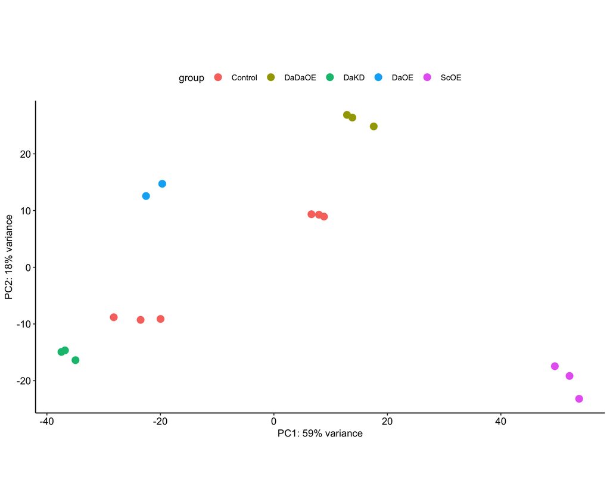

```r
vsd_Object <- vst(exptObject, blind=TRUE)
plotPCA(vsd_Object)
```

There’s a clear (and expected) batch effect: batch 1 is in PC1 negative values while batch 2 is in PCA1 positive values. Remove batch effect and re-plot:

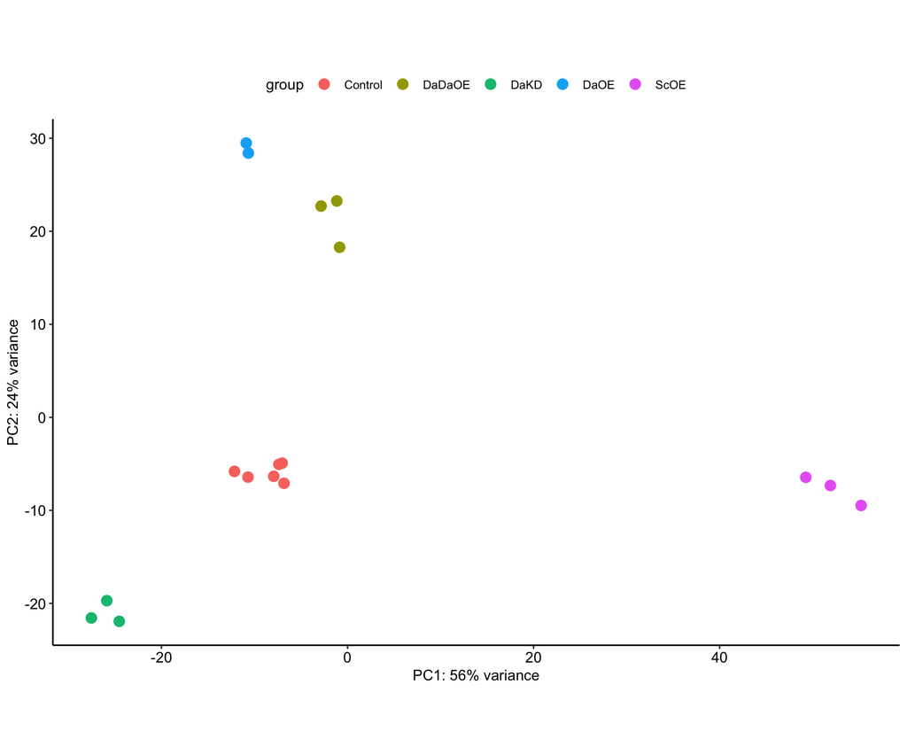

```r
assay(vsd_Object) <- removeBatchEffect(
  assay(vsd_Object),
  batch=vsd_Object$batch,
  design=model.matrix(~condition, colData(vsd_Object))
  )
plotPCA(vsd_Object)
```

```r
saveRDS(vsd_Object, file.path(dirpath, 'vst_pseudocounts_batchCorrected.RDS'))
```

### Sample correlations

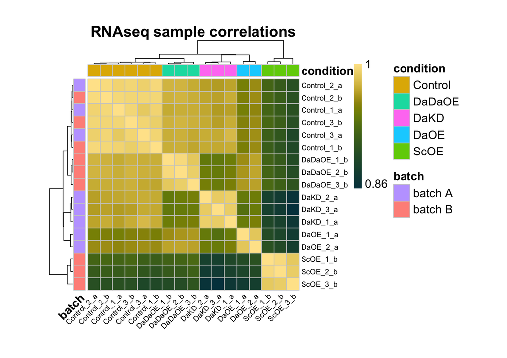

```r
# Compute the correlation values between samples
vsd_cor_Object <- cor(assay(vsd_Object))

# heatmap
main.title <- 'RNAseq sample correlations'
## get sorted clusters
sort_hclust <- function(x) as.hclust(dendsort(as.dendrogram(x)))
mat_cluster_cols <- hclust(dist(t(vsd_cor_Object)))
mat_cluster_cols <- sort_hclust(mat_cluster_cols)
mat_cluster_rows <- hclust(dist(vsd_cor_Object))
mat_cluster_rows <- sort_hclust(mat_cluster_rows)
## mark the batches
annot_batch <- data.frame(batch = ifelse(test = targets$Batch == 'a',
                                         yes = 'batch A',
                                         no = 'batch B'))
rownames(annot_batch) <- rownames(vsd_cor_Object)
## get minimum correlation value, rounded for the legend
bot <- ceiling(min(vsd_cor_Object)*100)/100
## plot
pheatmap(
  # data
    mat               = vsd_cor_Object,
    scale             = "none", # otherwise numbers are changed
    cellwidth         = 15,
    cellheight        = 15,
  # title
    main              = main.title,
    fontsize          = 14,
    annotation        = dplyr::select(exptDesign, condition),
  # rows
    cluster_rows      = mat_cluster_rows,
    treeheight_row    = 25, # default is 50
    show_rownames     = TRUE,
    labels_row        = rownames(exptDesign),
    fontsize_row      = 9,
    annotation_row    = annot_batch,
  # cols
    cluster_cols      = mat_cluster_cols,
    treeheight_col    = 25,
    show_colnames     = TRUE,
    labels_col        = rownames(exptDesign),
    fontsize_col      = 9,
    angle_col         = 45,
  # legends
    legend_breaks     = c(bot, 1),
  # tiles
    color             = scico(255, palette='bamako'),
    border_color      = 'grey80')
```

This is somewhat redundant with PCA but also makes sense, so we will save the `vsd_Object` for the descriptive visualisations.

```r
saveRDS(vsd_Object, file.path(dirpath, 'vsd.RDS'))
```

## 2.3 Visualise dispersion estimates

This will normalise the data, correct for dispersion (variance between replicates) and set data up for a differential comparison of any 2 conditions:

```r
analysisObject = DESeq(exptObject)
```

After fitting the data to a negative binomial model, some basic QC consists of plotting the dispersion estimates using the `plotDispEsts()` function. The dispersion estimates are used to model the raw counts, assuming (1) that dispersions will generally decrease with increasing mean, and (2) that they should more or less follow the fitted line.

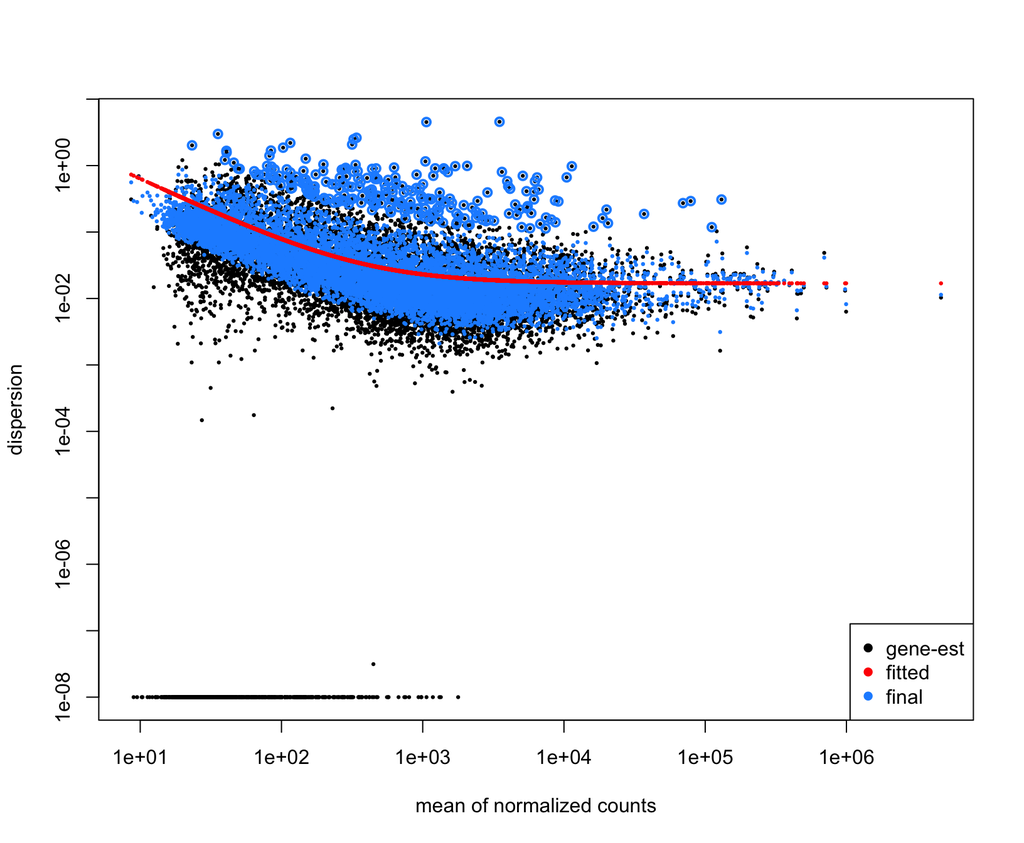

```r
plotDispEsts(analysisObject)
```

This seems reasonably in order, so we move on to saving the expression data for further visualisation and analysis, and Supplementary Data:

```r
rawCounts        <- as.data.frame(counts(analysisObject, normalized=FALSE))
normalisedCounts <- as.data.frame(counts(analysisObject, normalized=TRUE))
saveRDS(rawCounts, file.path(dirpath, 'rawCounts.RDS'))
saveRDS(normalisedCounts, file.path(dirpath, 'normalisedCounts.RDS'))
```

## 2.4 Differential gene expression

Loop over the experimental conditions and save `DESeq2::results` as RDS data:

```r
# to get a more informative naming for the samples:
targets$sampleIDs <- names(rawCounts)
# conditions to be tested
test_conditions <- unique( targets[targets$Condition != 'Control',]$Condition )
test_names <- paste0(rep('Control_vs_',length(test_conditions)),test_conditions)
tests <- as.list(rep(NA, length(test_names)))
names(tests) <- test_names

for (condtn in test_conditions) {
  # get the Counts for those conditions
  deData <- as.data.frame(results(analysisObject,
                                  contrast=c("condition", condtn, 'Control'), # Reference goes last!
                                  pAdjustMethod="BH"))
  # add column of ID
  deData <- cbind(data.frame('ensemblGeneID'=rownames(deData)), deData)
  # sort by pval
  deData <- deData[order(deData$pvalue), ]
  # add gene symbol column and reorder columns
  deData <- merge(deData, dlist, by=0)
  deData <- deData[,c(1,ncol(deData),2:(ncol(deData)-1))]
  # save for later
  saveRDS(deData, file=file.path(dirpath, paste0('Control_vs_', condtn, ".RDS")))
  # save as Supplementary data for publication
  cols <- c('gene_symbol', 'ensemblGeneID', 'log2FoldChange', 'padj')
  rownames(deData) <- NULL
  tests[[paste0('Control_vs_', condtn)]] <- deData %>% dplyr::select(all_of(cols))
}
```

(Note that in the parameter `contrast`, `'Control'` is last - I cannot find formal justification of this, but even with the `relevel`ling of the `condition` column of the experimental design object to make ‘Control’ the reference level, this needs to go last, or the log<sub>2</sub>FC values will have the opposite sign.)

### Supplementary Table S3

Now we just need to write the adjusted p-values and the log<sub>2</sub>(fold changes). That, with the raw counts, should be enough for anyone to do their own ‘light’ analysis without having to get any files from GEO.

```r
# add `rawCounts` to `tests`
tests <- rlist::list.append(tests, `Raw counts per gene per sample`=rawCounts)
# Supplementary data for publication
write_xlsx(tests, path = file.path('output', 'Table S3.xlsx'))
```

Finally, to have the experimental designed captured in a flexible manner for later on:

```r
targets$condition_md <- plyr::mapvalues(
  targets$Condition,
  from=unique(targets$Condition),
  to=c('*da^RNAi^*', '*da*', '*wild-type*', '*da:da*', '*scute*')
  )
targets$condition_md <- factor(
  targets$condition_md,
  c('*wild-type*', '*da*', '*da:da*','*da^RNAi^*', '*scute*')
  )
saveRDS(targets, file.path(dirpath, 'targets.RDS'))
```